# AI CA5

## Kasra Hajiheidari 810199400

```python
# !unzip "AI-CA5-Dataset"
from google.colab import drive
from PIL import Image
import torch
import matplotlib.pyplot as plt
import numpy as np
import torch.nn as nn
import torch.nn.functional as F
from torch.utils.data import random_split,DataLoader, TensorDataset,random_split
from torchvision import datasets, transforms
import torch.optim as optim
from sklearn.metrics import classification_report, confusion_matrix
import seaborn as sns
from torch.nn import Module, Sequential, Conv2d, BatchNorm2d, ReLU, MaxPool2d, Linear
from torch.autograd import Variable
from torch.optim import SGD,Adam
from torchvision.datasets import ImageFolder
from sklearn.model_selection import train_test_split
import sklearn.metrics
import seaborn as sn
import os
import gc
```

```python
drive.mount('/content/drive')
```

```python
dataset_folder_path = '/content/drive/MyDrive/AI-CA5-Dataset';
subfolders = ['pituitary', 'glioma', 'meningioma', 'notumor']

dataset = {subfolder: [] for subfolder in subfolders}

def preprocess_image(img_path):
    img = Image.open(img_path).convert('L')  # or 'RGB'
    img = img.resize((512, 512))
    return np.array(img)

for subfolder in subfolders:
    subfolder_path = os.path.join(dataset_folder_path, subfolder)
    if os.path.exists(subfolder_path):
        files = os.listdir(subfolder_path)
        for file in files:
            file_path = os.path.join(subfolder_path, file)
            img_array = preprocess_image(file_path)
            dataset[subfolder].append(img_array)
    else:
        print(f"The subfolder '{subfolder}' does not exist.")

for subfolder, images in dataset.items():
    print(f"\nPreprocessed images in '{subfolder}':")
    print(images[0].shape)
```

```
Preprocessed images in 'pituitary':
(512, 512)

Preprocessed images in 'glioma':
(512, 512)

Preprocessed images in 'meningioma':
(512, 512)

Preprocessed images in 'notumor':
(512, 512)
```

```python
for d in dataset:
  print("Number of",d,"images: ",len(dataset[d]))
```

```
Number of pituitary images:  300
Number of glioma images:  300
Number of meningioma images:  306
Number of notumor images:  405
```

```python
pituitary_images = dataset['pituitary']
glioma_images = dataset['glioma']
meningioma_images = dataset['meningioma']
notumor_images = dataset['notumor']
```

# Custom dataset class

```python
class MyImageDS():
    def __init__(self, class_name, imglist: list):
        self.class_name = class_name
        self.img_list = imglist

    def get_image(self, index):
       img = self.img_list[index]
       return transforms.ToTensor()(img)


mytransform = transforms.Compose([transforms.Resize((512, 512)),
                                  transforms.Grayscale(num_output_channels=1),
                                  transforms.ToTensor()])
img_dataset = datasets.ImageFolder(root=dataset_folder_path , transform=mytransform)

ds_list = [MyImageDS(d,dataset[d]) for d in dataset]
```

## Normalization

Normalization can significantly impact the training and performance of your neural network model. Here are some ways in which normalization can affect model accuracy:

- **Faster Convergence:**
  - Normalizing input features helps the optimization algorithm converge faster during training. This is because the optimization process is more efficient when the input values are centered around zero and have a standard deviation close to 1. Faster convergence can lead to quicker model training.
- **Stability during Training:**
  - Normalization helps stabilize the training process by preventing issues like exploding or vanishing gradients. This stability is crucial for deep neural networks, as it ensures that the gradients during backpropagation are within a reasonable range.
- **Improved Generalization:**
  - Normalization can contribute to better generalization performance. When the input features are normalized, the model is less likely to be sensitive to variations in input scales. This can result in a model that performs well not only on the training data but also on unseen data (validation or test sets).
- **Avoidance of Saturation:**
  - For activation functions like sigmoid or tanh, normalization helps avoid saturation of activations, which can occur when values are too large or too small. Saturation can lead to a loss of information during forward and backward passes.

In summary, normalization is a crucial preprocessing step that not only aids in the stability and efficiency of training but also contributes to the overall performance and generalization of the model. It is considered a good practice in deep learning workflows, and many neural network architectures. Normalizing pixel values in grayscale images helps in stabilizing the training process, speeding up convergence, and improving the generalization of your model. The fundamental idea is to scale the pixel values to a standardized range, typically centered around zero with a standard deviation close to 1.

```python
batch_size = 64

# Use a DataLoader to iterate over the dataset and calculate mean and std
loader = DataLoader(img_dataset, batch_size=batch_size, shuffle=False)

# Calculate mean and std
mean = 0.0
std = 0.0
total_samples = 0

for data, _ in loader:
    batch_samples = data.size(0)
    data = data.view(batch_samples, data.size(1), -1)
    mean += data.mean(2).sum(0)
    std += data.std(2).sum(0)
    total_samples += batch_samples

mean /= total_samples
std /= total_samples

print("Calculated Mean:", mean.tolist())
print("Calculated Std:", std.tolist())

# Using the calculated mean and std for normalization
transform_normalized = transforms.Compose([
    transforms.Grayscale(num_output_channels=1),
    transforms.Resize((512, 512)),  # Adjust the size as needed
    transforms.ToTensor(),
    transforms.Normalize(mean=mean.tolist(), std=std.tolist()),
])

# Apply the transform to dataset during data loading
dataset_normalized = ImageFolder(dataset_folder_path, transform=transform_normalized)
```

```
Calculated Mean: [0.1927345246076584]
Calculated Std: [0.18954861164093018]
```

## Split data to test and train

- The choice of the best percentage to split between training and testing data depends on several factors, and there's no one-size-fits-all answer. The optimal split often varies based on the size of your dataset, the complexity of your model, and the nature of your task.

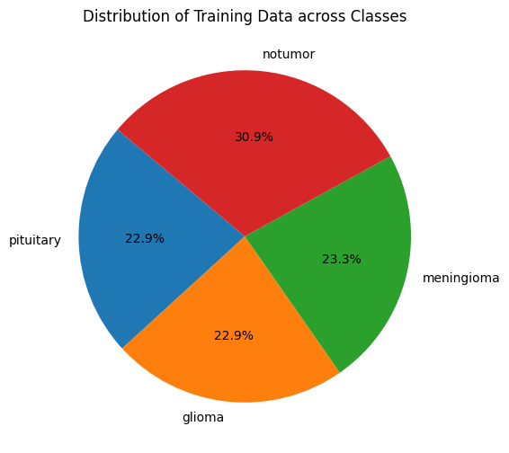

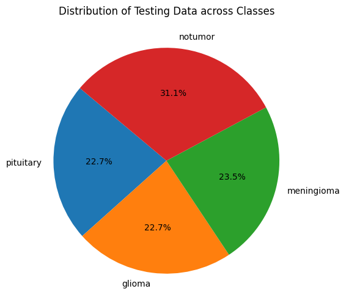

```python
train_test_list = [train_test_split(ds.img_list, test_size=0.1) for ds in ds_list]
s = 0
for i in ds_list:
    s += len(i.img_list)
testlen = int(0.1*s)
train, test = random_split(dataset_normalized, [s - testlen, testlen]) #img_dataset

plt.figure(figsize=(10, 6))
plt.title("Distribution of Training Data across Classes")
plt.pie([len(imglist[0]) for imglist in train_test_list], labels=[tmr.class_name for tmr in ds_list], autopct='%1.1f%%', startangle=140)
plt.show()

plt.figure(figsize=(10, 6))
plt.title("Distribution of Testing Data across Classes")
plt.pie([len(imglist[1]) for imglist in train_test_list], labels=[tmr.class_name for tmr in ds_list], autopct='%1.1f%%', startangle=140)
plt.show()
```

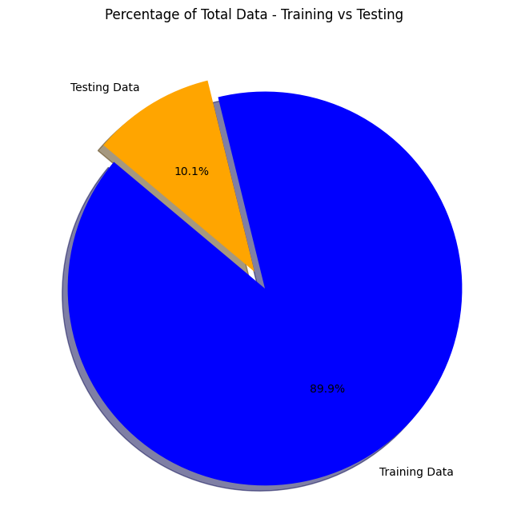

```python
total_train_data = sum(len(imglist[0]) for imglist in train_test_list)
total_test_data = sum(len(imglist[1]) for imglist in train_test_list)
total_data = total_train_data + total_test_data

percentage_train_data = (total_train_data / total_data) * 100
percentage_test_data = (total_test_data / total_data) * 100

plt.figure(figsize=(8, 8))
labels = ['Training Data', 'Testing Data']
sizes = [percentage_train_data, percentage_test_data]
colors = ['blue', 'orange']
explode = (0.1, 0)

plt.pie(sizes, explode=explode, labels=labels, colors=colors, autopct='%1.1f%%', shadow=True, startangle=140)
plt.title("Percentage of Total Data - Training vs Testing")
plt.show()
```

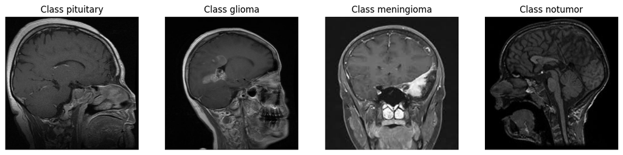

```python
class_indices_to_show = [0, 1, 2, 3]
fig, axs = plt.subplots(1, len(class_indices_to_show), figsize=(15, 5))

# Load and display one image from each class
i = 0
for d in ds_list:
    image = d.img_list[0]
    axs[i].imshow(image, cmap='gray')
    axs[i].axis('off')
    axs[i].set_title(f"Class {d.class_name}")
    i+=1

plt.show()
```

## Classification using CNN

```python
class CNN(nn.Module):
    def __init__(self):
        super(CNN, self).__init__()
        self.conv1 = nn.Conv2d(in_channels=1, out_channels=96, kernel_size=16, stride=8, padding=0) # 1x512x512 --> 96x((512-16)/8)+1x63
        self.pool1 = nn.MaxPool2d(3, 2) # 96x63x63 --> 96x((63-3)/2)+1x31
        self.conv2 = nn.Conv2d(96, 256, 5, 1, padding=2) # 96x31x31 --> 256x(31-5+1+2*2)x31
        self.pool2 = nn.MaxPool2d(3, 2) # 256x31x31 --> 256x((31-3)/2+1x15
        self.conv3 = nn.Conv2d(256, 384, 3, 1, 1) # 256x15x15 --> 384x(15-3+1+2*1)x15
        self.conv4 = nn.Conv2d(384, 384, 3, 1, 1) # 384x15x15 --> 384x15x15
        self.conv5 = nn.Conv2d(384, 256, 3, 1, 1) # 384x15x15 --> 256x15x15
        self.pool4 = nn.MaxPool2d(3, 2) # 256x15x15 --> 384x((15-3)/2+1)x7
        #nn layer
        self.fc1 = nn.Linear(256*7*7, 4096)
        self.fc2 = nn.Linear(4096, 4096)
        self.fc3 = nn.Linear(4096, 1024)
        self.fc4 = nn.Linear(1024, 4)

    def forward(self, x):
        out = self.pool1(F.relu(self.conv1(x)))
        out = self.pool2(F.relu(self.conv2(out)))
        out = F.relu(self.conv3(out))
        out = F.relu(self.conv4(out))
        out = self.pool4(F.relu(self.conv5(out)))
        out = out.flatten(start_dim=1)
        out = self.fc1(out)
        out = F.relu(self.fc2(out))
        out = F.relu(self.fc3(out))
        out = self.fc4(out)
        return out

mycnn = CNN()
```

Layers used in convolutional neural networks (CNNs):

1. **Convolutional Layer (Conv):**
   - **Purpose:** The convolutional layer is responsible for learning spatial hierarchies of features in an image.
   - **Operation:** It applies convolutional filters (kernels) to the input image to detect patterns, edges, and features. Each filter slides over the input, and the dot product with local input patches is calculated.
2. **Pooling Layer (Pool):**
   - **Purpose:** The pooling layer reduces the spatial dimensions of the input and helps create a more abstracted and compact representation.
   - **Operation:** Common pooling types include max pooling and average pooling. Max pooling takes the maximum value from a local region, while average pooling calculates the average.
3. **Fully Connected Layer (FC):**
   - **Purpose:** The fully connected layer connects every neuron from the previous layer to every neuron in the current layer.
   - **Operation:** Each neuron in the fully connected layer is connected to every output of the previous layer. It performs a weighted sum of its inputs and adds a bias, followed by an activation function.
4. **Rectified Linear Unit (ReLU):**
   - **Purpose:** The ReLU activation function introduces non-linearity to the model and helps the network learn complex patterns.
   - **Operation:** ReLU replaces all negative values in the input with zero and leaves positive values unchanged. It is a simple yet effective way to introduce non-linearity.
5. **Flatten Layer (Flatten):**
   - **Purpose:** The flatten layer reshapes the input into a one-dimensional vector, preparing it for input to a fully connected layer.
   - **Operation:** It takes the multi-dimensional output from the previous layer and flattens it into a one-dimensional vector.

## Cost function:

Cost functions, also known as loss functions play a crucial role in training machine learning models. They measure the difference between the predicted output of a model and the true target values. The goal during training is to minimize the value of the cost function, which essentially means making the model's predictions as close as possible to the actual values. Different types of tasks and models may require different cost functions. Here are some common cost functions for multiclass classification:

### 1. **Categorical Cross-Entropy Loss:**

- **Explanation:** Measures how well the predicted probabilities match the true class labels when the labels are one-hot encoded.

### 2. **Sparse Categorical Cross-Entropy Loss:**

- **Explanation:** Similar to categorical cross-entropy, but suitable when class labels are provided as integers.

### 3. **Softmax Cross-Entropy Loss:**

- **Explanation:** Encourages the model to produce a probability distribution over classes, ensuring that the predicted probabilities sum to 1.

### 4. **Kullback-Leibler Divergence (KLD) Loss:**

- **Explanation:** Measures the difference between the predicted distribution and the true distribution, emphasizing the divergence between them.

### 5. **Multiclass Margin Loss (SVM Loss):**

- **Explanation:** Used in Multiclass Support Vector Machines (SVMs), it encourages a clear margin between the predicted scores of correct and incorrect classes.

### 6. **Weighted Cross-Entropy Loss:**

- **Explanation:** Adjusts the impact of different classes on the overall loss, useful when there is an imbalance in class distribution.

These cost functions guide the training process by penalizing deviations between predicted and true class labels. The choice depends on the specific characteristics of the classification task and the desired behavior of the model during training.

```python
cost_func = nn.CrossEntropyLoss()
```

## Optimizer

**Stochastic Gradient Descent (SGD):**

- SGD is a widely used optimization algorithm for training machine learning models. It's a stochastic version of gradient descent, meaning it updates model parameters using the gradient of the loss function with respect to the parameters. In each iteration, SGD updates the parameters by moving in the direction opposite to the gradient, scaled by a learning rate. The learning rate determines the step size in the parameter space.
- **Advantages:**
  - Easy to implement.
  - Processes one training sample at a time, making it memory-efficient.
- **Disadvantages:**
  - The updates can be noisy due to the use of individual samples, leading to oscillations.
  - Requires careful tuning of the learning rate, and the same learning rate is applied to all parameters.

**Adam (Adaptive Moment Estimation):**

- Adam is an adaptive optimization algorithm that computes individual adaptive learning rates for different parameters. Adam maintains two moving averages for each parameter: the first moment (mean) and the second moment (uncentered variance). It then updates parameters using a combination of these moving averages, introducing adaptive learning rates.
- **Advantages:**
  - Adapts the learning rates for each parameter individually, providing more stable and effective updates.
  - Utilizes momentum-like terms to improve convergence in the presence of noise.
- **Disadvantages:**
  - Requires tuning of hyperparameters, including the exponential decay rates of the moving averages.

**Comparison:**

1. **Adaptability:**
   - **SGD:** Uses a fixed learning rate for all parameters.
   - **Adam:** Adapts the learning rate for each parameter based on historical gradients.
2. **Memory Efficiency:**
   - **SGD:** Processes one training sample at a time, making it memory-efficient.
   - **Adam:** Maintains additional moving averages, potentially requiring more memory.
3. **Convergence:**
   - **SGD:** May oscillate in the presence of noisy gradients.
   - **Adam:** Tends to converge faster and more reliably due to adaptive learning rates.
4. **Hyperparameters:**
   - **SGD:** Primarily requires tuning of a global learning rate.
   - **Adam:** Requires tuning of additional hyperparameters, such as exponential decay rates.
5. **Usage:**
   - **SGD:** Suitable for simple models and when memory efficiency is crucial.
   - **Adam:** Widely used for deep learning and complex models where adaptive learning rates can be beneficial.

Adam is often preferred for training deep learning models due to its adaptive learning rates, which can lead to faster and more stable convergence.

```python
myoptimizer = Adam(mycnn.parameters(), lr=0.0001)
```

## Training model

**Batch Size in Training:**

**Batch size** refers to the number of training examples utilized in one iteration. During each iteration (or epoch) of training, the entire dataset is divided into batches, and the model is updated based on the average gradient computed from each batch. The choice of batch size is an important hyperparameter in the training process.

**Effect of Batch Size:**

1. **Computational Efficiency:**
   - **Large Batch Size:** Typically leads to faster training, especially on hardware optimized for parallel processing (like GPUs). This is because larger batches allow for better utilization of parallelism.
   - **Small Batch Size:** May result in slower training due to the overhead of processing smaller batches. However, it might be necessary in situations with limited memory resources.
2. **Generalization:**
   - **Large Batch Size:** Tends to converge faster but may lead to a model that generalizes less well to the validation or test set. Larger batches provide a smoother and more accurate estimate of the gradient, but they may cause the model to converge to sharp minimizers, resulting in overfitting.
   - **Small Batch Size:** May lead to better generalization, as the stochastic nature of the smaller batches introduces noise, preventing the model from converging to sharp minimizers. Smaller batches can help the model explore a larger portion of the parameter space.
3. **Memory Requirements:**
   - **Large Batch Size:** Requires more memory, which can be a limitation on devices with limited GPU memory or when dealing with large datasets.
   - **Small Batch Size:** Requires less memory, making it more suitable for situations with resource constraints.
4. **Stochasticity:**
   - **Large Batch Size:** Reduces the stochasticity in the training process. The model parameters are updated less frequently, and the optimization process may be more deterministic.
   - **Small Batch Size:** Introduces more randomness due to the frequent parameter updates. This can be beneficial in escaping local minima and exploring different regions of the loss landscape.
5. **Convergence Speed:**
   - **Large Batch Size:** Tends to converge faster, but the final convergence might not be as good as with smaller batch sizes.
   - **Small Batch Size:** Convergence may be slower, but the final model might have better generalization.

The choice of batch size depends on the specific characteristics of the dataset, the available hardware resources, and the desired trade-off between computational efficiency and model generalization.

```python
train_loader = DataLoader(train, batch_size=16, num_workers=2, shuffle=True, drop_last=False)
test_loader = DataLoader(test, batch_size=16, num_workers=2, shuffle=False, drop_last=False)
```

```python
# device = torch.device('cuda:0' if torch.cuda.is_available() else 'cpu')
device = torch.device('cpu')
print(device)
from tensorflow.python.client import device_lib
device_lib.list_local_devices()
```

```
cpu
```

[output not shown]

```python
device = torch.device('cuda:0' if torch.cuda.is_available() else 'cpu')

def train_test_model(device: torch.device, optimizer: torch.optim,
                     train_loader: DataLoader, test_loader: DataLoader,
                     cost_func, cnn: nn.Module):
    train_acc = []
    test_acc = []
    train_loss = []
    test_loss = []
    preds = []
    trues = []
    cnn = cnn.to(device)
    for epoch in range(29):
        running_loss = 0.0
        total_train = 0
        correct_train = 0
        cnn.train(True)
        for inputs, labels in train_loader:
            inputs, labels = inputs.to(device), labels.to(device)
            optimizer.zero_grad()
            outputs = cnn(inputs)
            loss = cost_func(outputs, labels)
            loss.backward()
            optimizer.step()
            running_loss += loss.item()
            _, train_pred = torch.max(outputs.data, 1)
            total_train += labels.size(0)
            correct_train += (train_pred == labels).sum().item()

        tacc = 100*correct_train/total_train
        train_acc.append(tacc)
        train_loss.append(running_loss)
        print("for epoch: ", epoch)
        print("\tTrain Acc: ", tacc, ", Train Loss: ", running_loss/len(train_loader))

        total_test = 0
        correct_test = 0
        loss_test = 0.0
        cnn.eval()
        with torch.no_grad():
            for inp, lab in test_loader:
                inp, lab = inp.to(device), lab.to(device)
                out = cnn(inp)
                _, pred = torch.max(out.data, 1)
                preds += pred.tolist()
                trues += lab.tolist()

                total_test += lab.size(0)
                correct_test += (pred == lab).sum()
                loss_test += cost_func(out, lab)
                gc.collect()
            tsacc = 100*correct_test.item()/total_test
            test_acc.append(tsacc)
            test_loss.append(loss_test.item())
            print("\tTest Acc: ", tsacc, ", Test Loss: ", loss_test.item()/len(test_loader))
        torch.cuda.empty_cache()

    return train_acc, test_acc, train_loss, test_loss, preds, trues ,

train_acc, test_acc, train_loss, test_loss, preds, trues = train_test_model(device, myoptimizer, train_loader, test_loader,cost_func, mycnn)
```

```
for epoch:  0
	Train Acc:  45.50847457627118 , Train Loss:  1.193549020870312
	Test Acc:  54.19847328244275 , Test Loss:  1.071154276529948
for epoch:  1
	Train Acc:  63.389830508474574 , Train Loss:  0.8953018905343236
	Test Acc:  68.70229007633588 , Test Loss:  0.8654957877265083
for epoch:  2
	Train Acc:  70.76271186440678 , Train Loss:  0.6716522940912762
	Test Acc:  74.80916030534351 , Test Loss:  0.6180792384677463
for epoch:  3
	Train Acc:  79.66101694915254 , Train Loss:  0.5324487951961724
	Test Acc:  76.33587786259542 , Test Loss:  0.5470868746439616
for epoch:  4
	Train Acc:  81.1864406779661 , Train Loss:  0.4547512190970215
	Test Acc:  80.1526717557252 , Test Loss:  0.5441557566324869
for epoch:  5
	Train Acc:  83.89830508474576 , Train Loss:  0.4062947367091437
	Test Acc:  78.62595419847328 , Test Loss:  0.502247068617079
for epoch:  6
	Train Acc:  87.88135593220339 , Train Loss:  0.31449799310113935
	Test Acc:  85.49618320610686 , Test Loss:  0.46731270684136283
for epoch:  7
	Train Acc:  90.16949152542372 , Train Loss:  0.23907569644821658
	Test Acc:  83.20610687022901 , Test Loss:  0.5448987219068739
for epoch:  8
	Train Acc:  92.79661016949153 , Train Loss:  0.20426159090286977
	Test Acc:  87.02290076335878 , Test Loss:  0.3410053782992893
for epoch:  9
	Train Acc:  93.89830508474576 , Train Loss:  0.15044484402421182
	Test Acc:  83.20610687022901 , Test Loss:  0.3730751938290066
for epoch:  10
	Train Acc:  94.83050847457628 , Train Loss:  0.13584657080119122
	Test Acc:  80.1526717557252 , Test Loss:  0.6873354911804199
for epoch:  11
	Train Acc:  92.79661016949153 , Train Loss:  0.19507121445132872
	Test Acc:  87.02290076335878 , Test Loss:  0.4438936445448134
for epoch:  12
	Train Acc:  95.59322033898304 , Train Loss:  0.11916460087868964
	Test Acc:  85.49618320610686 , Test Loss:  0.54376220703125
for epoch:  13
```

[output cut: 32 more lines]

```
for epoch:  24
	Train Acc:  99.32203389830508 , Train Loss:  0.030731248313099355
	Test Acc:  86.25954198473282 , Test Loss:  0.7753396564059787
for epoch:  25
	Train Acc:  100.0 , Train Loss:  0.0015111860106104802
	Test Acc:  87.78625954198473 , Test Loss:  0.7223942544725206
for epoch:  26
	Train Acc:  99.49152542372882 , Train Loss:  0.017449985968129557
	Test Acc:  87.02290076335878 , Test Loss:  0.7065079477098253
for epoch:  27
	Train Acc:  97.96610169491525 , Train Loss:  0.07469334277226841
	Test Acc:  90.83969465648855 , Test Loss:  0.47797346115112305
for epoch:  28
	Train Acc:  99.32203389830508 , Train Loss:  0.03672321752720883
	Test Acc:  84.73282442748092 , Test Loss:  0.7461024390326606
```

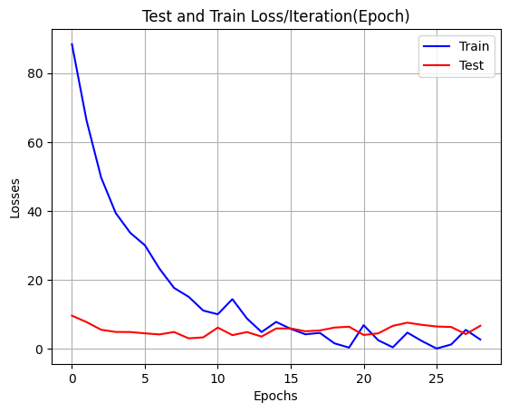

```python
plt.title("Test and Train Loss/Iteration(Epoch)")
plt.xlabel("Epochs")
plt.ylabel("Losses")
plt.plot([i for i in range(29)], train_loss, color='blue')
plt.plot([i for i in range(29)], test_loss, color='red')
plt.grid()
plt.legend(["Train", "Test"], loc='best')
plt.show()
```

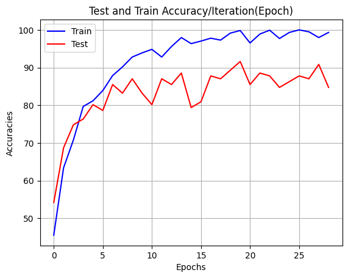

```python
plt.title("Test and Train Accuracy/Iteration(Epoch)")
plt.xlabel("Epochs")
plt.ylabel("Accuracies")
plt.plot([i for i in range(29)], train_acc, color='blue')
plt.plot([i for i in range(29)], test_acc, color='red')
plt.grid()
plt.legend(["Train", "Test"], loc='best')
plt.show()
```

## Regularization

Certainly! Let's simplify the explanations for regularization, dropout, and batch normalization:

### **Regularization:**

- Regularization is a technique used to prevent overfitting in machine learning models. It involves adding a penalty term to the loss function that discourages the model from assigning too much importance to any single feature or combination of features. This helps in creating a simpler model that generalizes well to new, unseen data.

### **Dropout:**

- Dropout is a regularization technique specifically designed for neural networks. During training, random neurons are "dropped out" or omitted from the forward and backward passes with a certain probability. This prevents the network from relying too heavily on specific neurons, forcing it to learn more robust features and improving generalization.

### **Batch Normalization:**

- Batch normalization is a technique used to improve the training of deep neural networks. It normalizes the inputs of each layer in a mini-batch by subtracting the batch mean and dividing by the batch standard deviation. This helps stabilize and speed up the training process by reducing internal covariate shift, making the optimization landscape more consistent during training.
- **Regularization** helps prevent overfitting by adding a penalty to the loss function.
- **Dropout** prevents over-reliance on specific neurons during training, promoting better generalization in neural networks.
- **Batch Normalization** normalizes layer inputs to stabilize and accelerate the training of deep neural networks.

These techniques contribute to the overall stability, generalization, and performance of machine learning models.

```python
device = torch.device('cuda:0' if torch.cuda.is_available() else 'cpu')
rgtrain_loader = DataLoader(train, batch_size=128, num_workers=2, shuffle=True, drop_last=False)
rgtest_loader = DataLoader(test, batch_size=128, num_workers=2, shuffle=False, drop_last=False)
class RegCNN(nn.Module):
    def __init__(self):
        super(RegCNN, self).__init__()
        self.conv1 = nn.Conv2d(in_channels=1, out_channels=96, kernel_size=16, stride=8, padding=0)                # 1x512x512 --> 96x((512-16)/8)+1x63
        self.pool1 = nn.MaxPool2d(3, 2)                  # 96x63x63 --> 96x((63-3)/2)+1x31
        self.bat1 = nn.BatchNorm2d(96)

        self.conv2 = nn.Conv2d(96, 256, 5, 1, padding=2) # 96x31x31 --> 256x(31-5+1+2*2)x31
        self.pool2 = nn.MaxPool2d(3, 2)                  # 256x31x31 --> 256x((31-3)/2+1x15
        self.bat2 = nn.BatchNorm2d(256)

        self.conv3 = nn.Conv2d(256, 384, 3, 1, 1)        # 256x15x15 --> 384x(15-3+1+2*1)x15
        self.conv4 = nn.Conv2d(384, 384, 3, 1, 1)        # 384x15x15 --> 384x15x15
        self.conv5 = nn.Conv2d(384, 256, 3, 1, 1)        # 384x15x15 --> 256x15x15
        self.pool4 = nn.MaxPool2d(3, 2)                  # 256x15x15 --> 384x((15-3)/2+1)x7
        self.bat3 = nn.BatchNorm2d(256)

        self.fc1 = nn.Linear(256*7*7, 4096)
        self.drop1 = nn.Dropout(p=0.25)
        self.fc2 = nn.Linear(4096, 4096)
        self.drop2 = nn.Dropout(p=0.25)
        self.fc3 = nn.Linear(4096, 4)


    def forward(self, x):
        out = self.pool1(self.bat1(F.relu(self.conv1(x))))
        out = self.pool2(F.relu(self.conv2(out)))
        out = F.relu(self.conv3(out))
        out = F.relu(self.conv4(out))
        out = self.pool4(F.relu(self.conv5(out)))
        out = out.flatten(start_dim=1)
        out = self.drop1(out)
        out = self.fc1(out)
        out = F.relu(self.fc2(out))
        out = self.drop2(out)
        out = F.relu(self.fc3(out))
        return out
regcnn = RegCNN()
```

```python
regoptimizer = Adam(regcnn.parameters(), lr=0.0001)
reg_train_acc, reg_test_acc, reg_train_loss, reg_test_loss, rgpreds, rgtrues = train_test_model(device,
                                                                              regoptimizer,
                                                                              rgtrain_loader,
                                                                              rgtest_loader,
                                                                              cost_func,
                                                                              regcnn)
```

```
for epoch:  0
	Train Acc:  42.54237288135593 , Train Loss:  1.2373282074928285
	Test Acc:  40.458015267175576 , Test Loss:  1.6413565874099731
for epoch:  1
	Train Acc:  55.0 , Train Loss:  1.03672314286232
	Test Acc:  39.69465648854962 , Test Loss:  1.3444716930389404
for epoch:  2
	Train Acc:  65.59322033898304 , Train Loss:  0.8638379335403442
	Test Acc:  69.46564885496183 , Test Loss:  0.8194484114646912
for epoch:  3
	Train Acc:  70.0 , Train Loss:  0.7106098473072052
	Test Acc:  73.2824427480916 , Test Loss:  0.6153311729431152
for epoch:  4
	Train Acc:  77.96610169491525 , Train Loss:  0.5765933692455292
	Test Acc:  78.62595419847328 , Test Loss:  0.4825078845024109
for epoch:  5
	Train Acc:  77.88135593220339 , Train Loss:  0.5205897331237793
	Test Acc:  76.33587786259542 , Test Loss:  0.43103110790252686
for epoch:  6
	Train Acc:  78.89830508474576 , Train Loss:  0.4650674343109131
	Test Acc:  76.33587786259542 , Test Loss:  0.815999448299408
for epoch:  7
	Train Acc:  79.23728813559322 , Train Loss:  0.5285792827606202
	Test Acc:  80.1526717557252 , Test Loss:  0.4693319499492645
for epoch:  8
	Train Acc:  78.47457627118644 , Train Loss:  0.4994758188724518
	Test Acc:  78.62595419847328 , Test Loss:  0.35177624225616455
for epoch:  9
	Train Acc:  83.13559322033899 , Train Loss:  0.38490208685398103
	Test Acc:  75.57251908396947 , Test Loss:  0.36375316977500916
for epoch:  10
	Train Acc:  83.89830508474576 , Train Loss:  0.3636616230010986
	Test Acc:  74.80916030534351 , Test Loss:  0.3427850008010864
for epoch:  11
	Train Acc:  86.86440677966101 , Train Loss:  0.30774077475070954
	Test Acc:  79.38931297709924 , Test Loss:  0.4235970973968506
for epoch:  12
	Train Acc:  89.57627118644068 , Train Loss:  0.2551475644111633
	Test Acc:  85.49618320610686 , Test Loss:  0.2774841785430908
for epoch:  13
```

[output cut: 32 more lines]

```
for epoch:  24
	Train Acc:  99.15254237288136 , Train Loss:  0.023837326793000102
	Test Acc:  88.54961832061069 , Test Loss:  0.3436284363269806
for epoch:  25
	Train Acc:  99.66101694915254 , Train Loss:  0.015528177563101053
	Test Acc:  90.07633587786259 , Test Loss:  0.37730708718299866
for epoch:  26
	Train Acc:  99.7457627118644 , Train Loss:  0.014183901227079332
	Test Acc:  88.54961832061069 , Test Loss:  0.4248155355453491
for epoch:  27
	Train Acc:  99.66101694915254 , Train Loss:  0.014561222516931593
	Test Acc:  90.83969465648855 , Test Loss:  0.3756280839443207
for epoch:  28
	Train Acc:  99.91525423728814 , Train Loss:  0.006889362330548465
	Test Acc:  87.02290076335878 , Test Loss:  0.3958715498447418
```

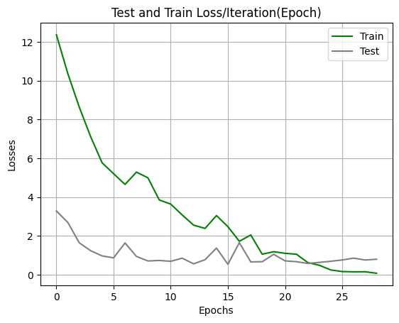

```python
plt.title("Test and Train Loss/Iteration(Epoch)")
plt.xlabel("Epochs")
plt.ylabel("Losses")
plt.plot([i for i in range(29)], reg_train_loss, color='green')
plt.plot([i for i in range(29)], reg_test_loss, color='gray')
plt.grid()
plt.legend(["Train", "Test"], loc='best')
plt.show()
```

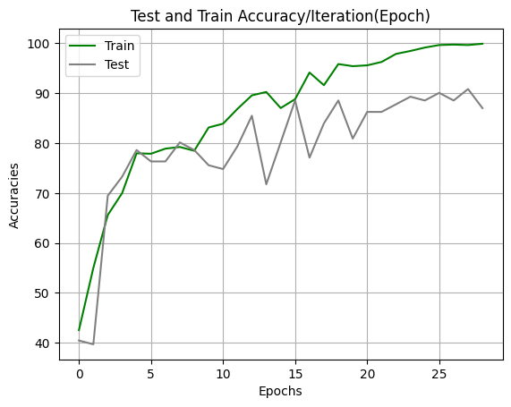

```python
plt.title("Test and Train Accuracy/Iteration(Epoch)")
plt.xlabel("Epochs")
plt.ylabel("Accuracies")
plt.plot([i for i in range(29)], reg_train_acc, color='green')
plt.plot([i for i in range(29)], reg_test_acc, color='gray')
plt.grid()
plt.legend(["Train", "Test"], loc='best')
plt.show()
```

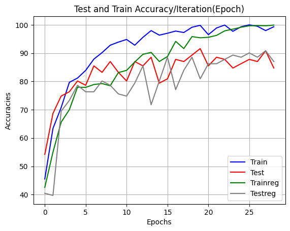

```python
plt.title("Test and Train Accuracy/Iteration(Epoch)")
plt.xlabel("Epochs")
plt.ylabel("Accuracies")
plt.plot([i for i in range(29)], train_acc, color='blue')
plt.plot([i for i in range(29)], test_acc, color='red')
plt.plot([i for i in range(29)], reg_train_acc, color='green')
plt.plot([i for i in range(29)], reg_test_acc, color='gray')
plt.grid()
plt.legend(["Train", "Test", "Trainreg", "Testreg"], loc='best')
plt.show()
```

```python
cdict = {
    0: "giloma",
    1: "meningioma",
    2: "notumor",
    3: "pituitary",
    "giloma": "giloma",
    "meningioma": "meningioma",
    "notumor": "notumor",
    "pituitary": "pituitary",
    }

def mapper(inp):
  temp = []
  for i in inp:
    temp.append(cdict[i])
  return temp
```

```
Metrics:
              precision    recall  f1-score   support

      giloma       0.84      0.85      0.85       986
  meningioma       0.72      0.64      0.68       870
     notumor       0.84      0.93      0.88      1160
   pituitary       0.92      0.88      0.90       783

    accuracy                           0.83      3799
   macro avg       0.83      0.82      0.83      3799
weighted avg       0.83      0.83      0.83      3799
```

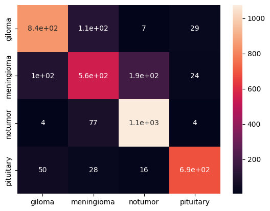

```python
preds = mapper(preds)
trues = mapper(trues)
print("Metrics: ")
print(sklearn.metrics.classification_report(trues, preds))

sn.heatmap(sklearn.metrics.confusion_matrix(trues, preds), annot=True,
           xticklabels=list(cdict.keys())[4:], yticklabels=list(cdict.keys())[4:])
```

```
Metrics:
              precision    recall  f1-score   support

      giloma       0.84      0.78      0.81       986
  meningioma       0.64      0.56      0.60       870
     notumor       0.80      0.93      0.86      1160
   pituitary       0.87      0.86      0.86       783

    accuracy                           0.79      3799
   macro avg       0.79      0.78      0.78      3799
weighted avg       0.79      0.79      0.79      3799
```

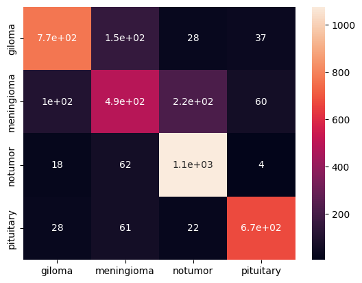

```python
rgpreds = mapper(rgpreds)
rgtrues = mapper(rgtrues)

print("Metrics: ")
print(sklearn.metrics.classification_report(rgtrues, rgpreds))
sn.heatmap(sklearn.metrics.confusion_matrix(rgtrues, rgpreds), annot=True,
                      xticklabels=list(cdict.keys())[4:], yticklabels=list(cdict.keys())[4:])
```